# Data mining exercise

# Introduction

Your collaborator has made a CAGE experiment using 7 different tissues. As a remainder, CAGE tags are 20-21 nt long tags mapping to the genome. We often cluster CAGE tags that are close to one another on the genome to a “tag cluster”. A tag cluster can then have several tags from one or several tissues.

One can view these CAGE tag clusters as being “core promoters” in the sense that they are measuring the activity and location of a core promoter.

The data file `htbinf_cage_tpms` shows the CAGE tag clusters as rows, and tissues as columns. The cell values are the TPMs from the given tissue in the cluster. There are three additional columns: the tag cluster ID, the location of the cluster in mm8 and the strand of the cluster. The collaborator now wants to know:

**1. How many types of core promoters are there in terms of tissue expression patterns, and what expression patterns are these?**

```r
cage_data = read_tsv('htbinf_cage_tpms.txt')
cage_matrix = as.matrix(cage_data[,4:10])
head(cage_data)
```

```
## # A tibble: 6 x 10
##   tc_id       location    strand   cer   emb   liv   lun   mac   som   vis
##   <chr>       <chr>       <chr>  <dbl> <dbl> <dbl> <dbl> <dbl> <dbl> <dbl>
## 1 C13F574BB4D chr13:9153… F      11.8   0     3.28 0.770     0  4.79  8.60
## 2 C3F83AF23B  chr3:13808… F      11.8   3.16  3.28 5.39      0  9.57  8.60
## 3 C14R30790AF chr14:5082… R       7.90  3.16  4.92 5.39      0  9.57 17.2
## 4 C5R67B8760  chr5:10875… R      11.8   3.16  4.92 5.39      0  9.57  8.60
## 5 CXF7D12F28  chrX:13114… F      11.8   3.16  4.92 5.39      0  9.57  8.60
## 6 C7F5DF20B4  chr7:98508… F      11.8   3.16  4.92 5.39      0  9.57  8.60
```

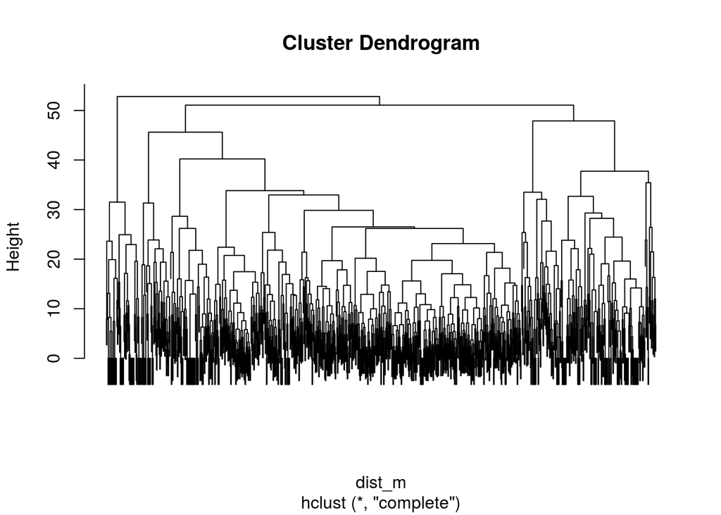

```r
dist_m = dist(cage_matrix)
mytree = hclust(dist_m)
plot(mytree, labels=F)
```

```r
# Kmeans
my_groups = kmeans(cage_matrix, 6)$cluster
my_pca = prcomp(cage_matrix, scale=T, center=T)
summary(my_pca)
```

```
## Importance of components:
##                           PC1    PC2    PC3    PC4    PC5    PC6    PC7
## Standard deviation     1.1322 1.0600 1.0369 0.9992 0.9924 0.9143 0.8367
## Proportion of Variance 0.1831 0.1605 0.1536 0.1426 0.1407 0.1194 0.1000
## Cumulative Proportion  0.1831 0.3437 0.4972 0.6399 0.7806 0.9000 1.0000
```

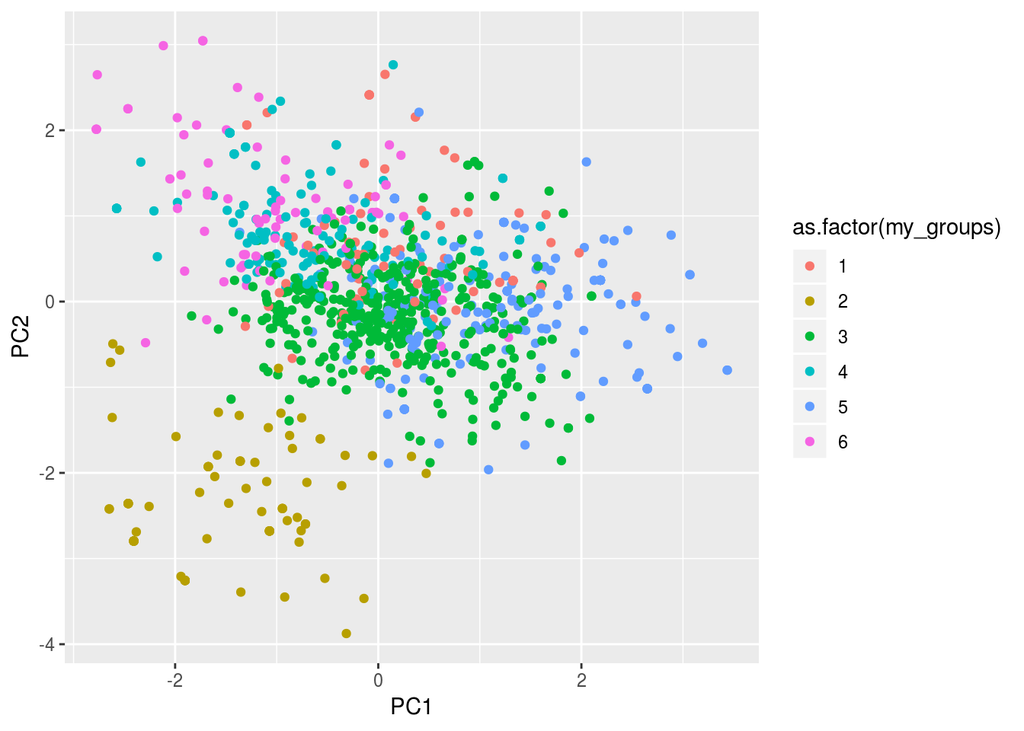

```r
my_pcax = my_pca$x
result = as.tibble(cbind(my_pcax, my_groups))
result %>% ggplot(aes(x=PC1, y=PC2, color=as.factor(my_groups))) + geom_point()
```

**2. What tissues are similar to each other in terms of promoter usage? They would really like to have this as a picture and not just “values”**

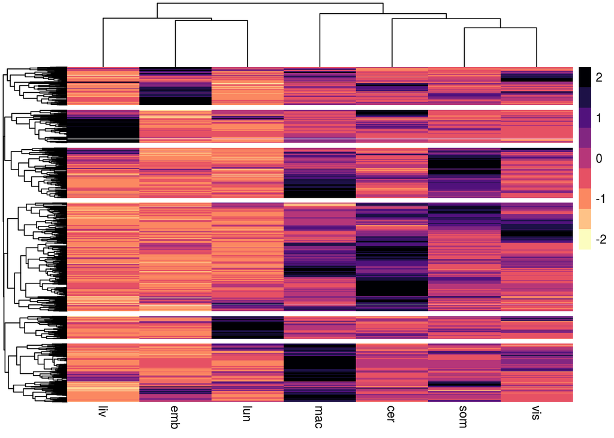

```r
pheatmap(cage_matrix, scale='row', color=magma(9, direction=-1), cutree_rows=6)
```

**3. How many tissue-specific promoters are there, per tissue and just allover? It would be very helpful to calculate two “specificity scores”: one for each tissue, and one summary score across all tissues for each promoter.**

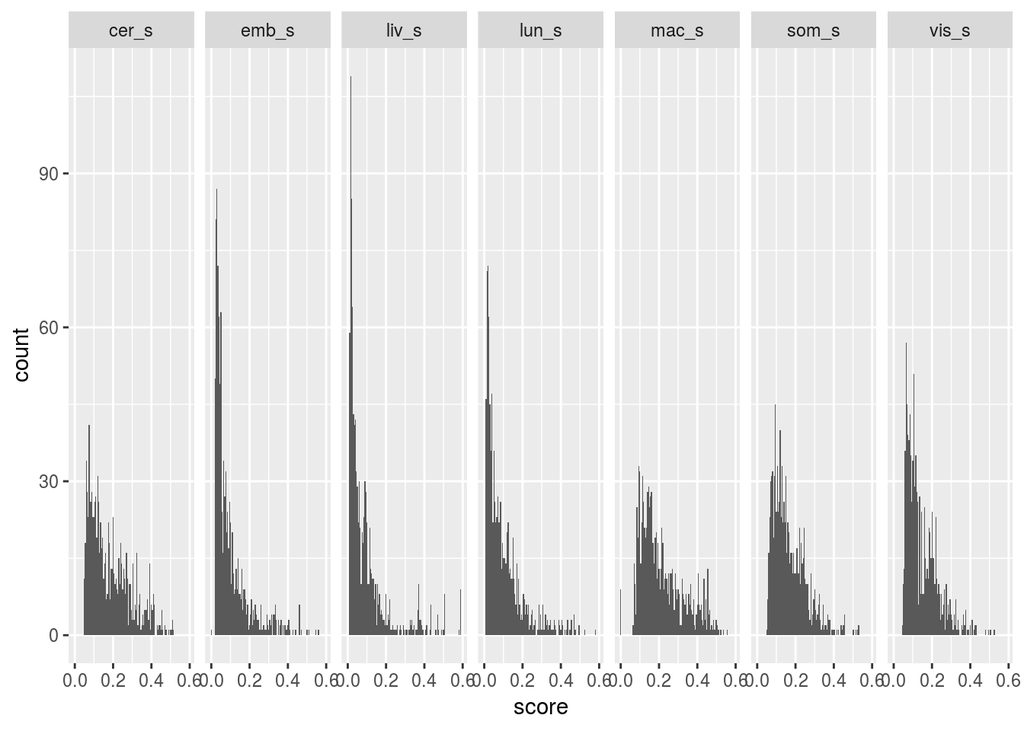

```r
cage_data = cage_data %>% rowwise() %>% mutate(sum = sum(liv,emb,lun,mac,cer,som,vis))
proc_data = cage_data %>% rowwise() %>%
  mutate(cer_s = cer/sum,
         emb_s = emb/sum,
         liv_s = liv/sum,
         lun_s = lun/sum,
         mac_s = mac/sum,
         som_s = som/sum,
         vis_s = vis/sum) %>% select(-strand, -location, -sum)
cutoff = 0.5
gat = proc_data %>% select(-cer,-emb,-liv,-lun,-mac,-som,-vis) %>%
  gather(key=tissue, value=score, cer_s, emb_s,liv_s,lun_s,mac_s,som_s, vis_s)

ggplot(gat, aes(x=score)) + geom_histogram(binwidth = 0.005) + facet_grid(~tissue)
```

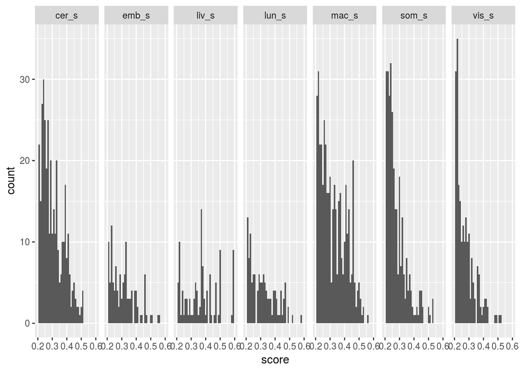

```r
ggplot(gat, aes(x=score)) + geom_histogram(binwidth = 0.01) +
  xlim(0.2, 0.6) +
  facet_grid(~tissue)
```

```r
specific = proc_data %>%
  filter(cer_s>cutoff | emb_s>cutoff | liv_s>cutoff | lun_s>cutoff | mac_s>cutoff | som_s>cutoff | vis_s>cutoff)

gat %>% group_by(tissue) %>% filter(score>cutoff) %>% summarise(count = n())
```

```
## # A tibble: 7 x 2
##   tissue count
##   <chr>  <int>
## 1 cer_s      6
## 2 emb_s      4
## 3 liv_s     18
## 4 lun_s      2
## 5 mac_s      8
## 6 som_s      5
## 7 vis_s      2
```

**4. They want to have genome browser examples of the most tissue-specific promoter for each tissue**

```r
spec_proms = gat %>% arrange(tissue, desc(score)) %>% distinct(tissue, .keep_all = T)
matrix(unlist(strsplit((cage_data %>%
          filter(tc_id %in% spec_proms$tc_id) %>%
          select(tc_id, location,strand))$location,
         split = '[:-]')), ncol = 3, byrow=T) %>%
  as.tibble %>%
  mutate(tc_id=spec_proms$tc_id) %>% write_tsv('prom.bed')
spec_proms
```

```
## # A tibble: 7 x 3
##   tc_id       tissue score
##   <chr>       <chr>  <dbl>
## 1 C11R616768B cer_s  0.514
## 2 C3R5BE2A40  emb_s  0.558
## 3 C3R7B86134  liv_s  0.588
## 4 C12F6991EBA lun_s  0.580
## 5 C13R35017AA mac_s  0.555
## 6 C2F8175E9D  som_s  0.532
## 7 CXF1F1DADB  vis_s  0.525
```

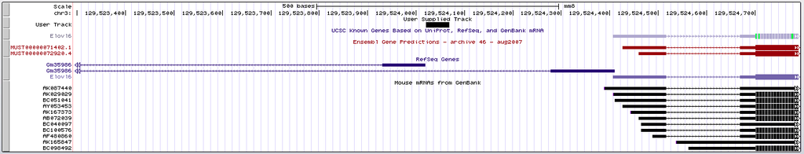

Genome browser, liver tissue promoter

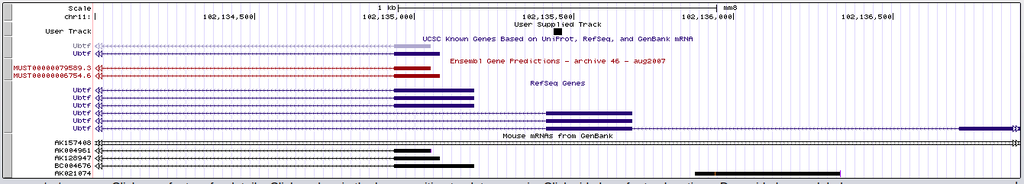

Genome browser, cerebellum tissue promoter

**5 Lastly, they want a list with the 10 most tissue-specific promoters, taking all tissues into account.**

```r
top_prom = gat %>% arrange(desc(score)) %>% head(10)
top_prom
```

```
## # A tibble: 10 x 3
##    tc_id       tissue score
##    <chr>       <chr>  <dbl>
##  1 C3R7B86134  liv_s  0.588
##  2 C5R564F0B1  liv_s  0.588
##  3 C8F53B7835  liv_s  0.588
##  4 C8F6BA7E07  liv_s  0.588
##  5 C9F2BE3351  liv_s  0.588
##  6 C6R53B58AA  liv_s  0.588
##  7 C17F2174305 liv_s  0.588
##  8 C10R177717A liv_s  0.588
##  9 C13F43FFEA  liv_s  0.588
## 10 C12F6991EBA lun_s  0.580
```

```r
matrix(unlist(strsplit((cage_data %>%
          filter(tc_id %in% top_prom$tc_id) %>%
          select(tc_id, location,strand))$location,
         split = '[:-]')), ncol = 3, byrow=T) %>%
  as.tibble %>%
  mutate(tc_id=top_prom$tc_id) %>% write_tsv('top_prom.bed')
```